# Triangular Orbits in Elliptic Billards: Loci of Points X(1)~X(100)

Dan Reznik

May, 2019

We consider triangular orbits in elliptic billiards and the loci of their triangular *centers* [1], specifically $X(1)$ to $X(100)$ as defined in [2], for a billiard with $a/b=1.5$. In the pictures below, the billiard is shown in *black*, loci of the orbit’s center in *blue*, and loci of the orbit’s *extriangle* shown in *green*, referred below as $X'(n)$.

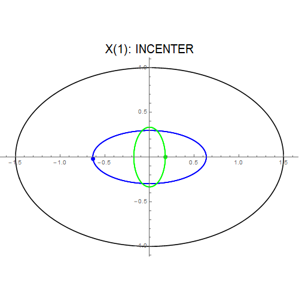

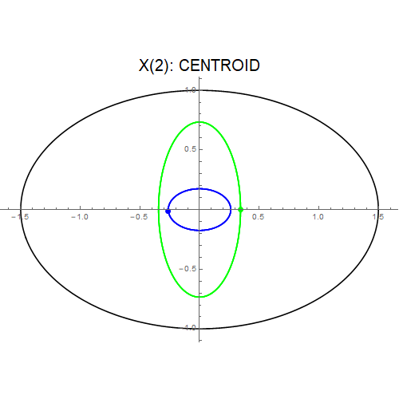

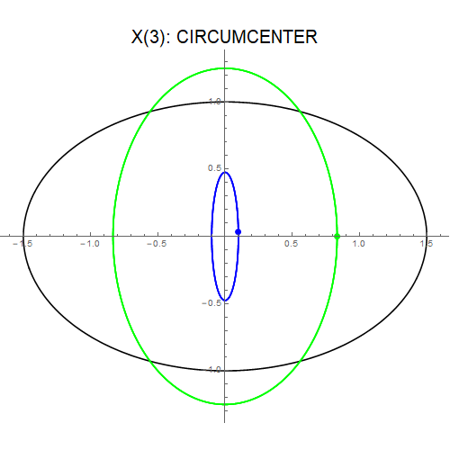

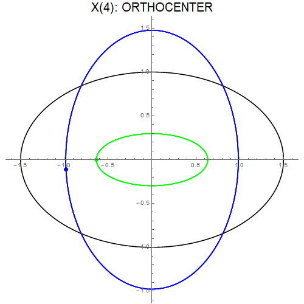

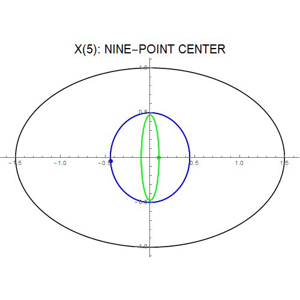

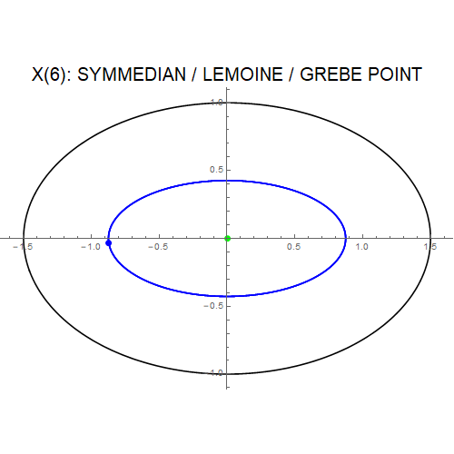

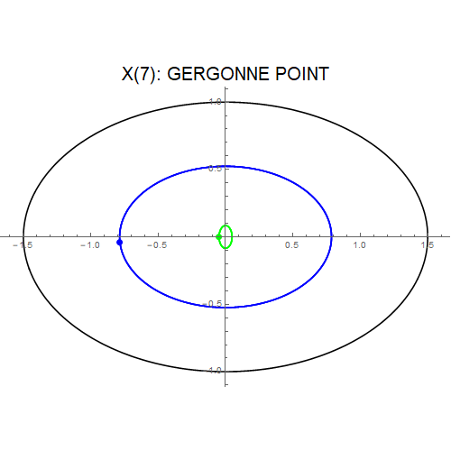

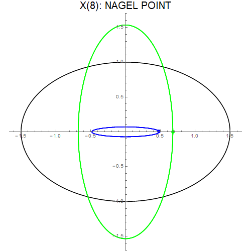

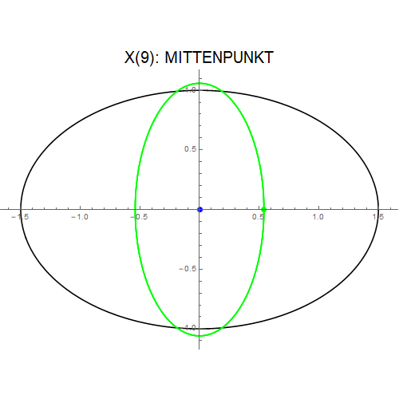

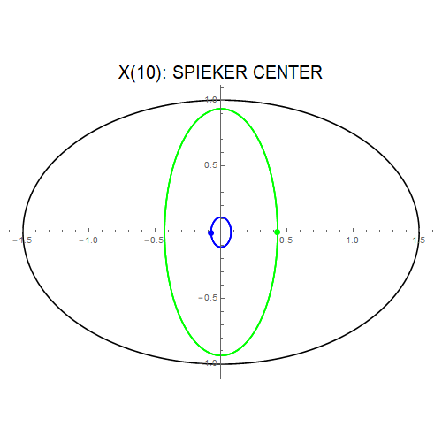

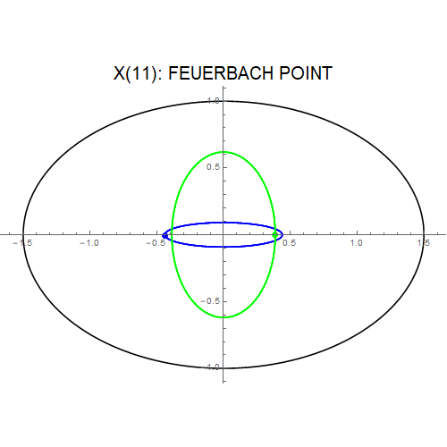

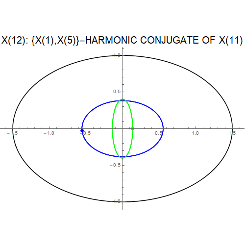

[88 more figures not shown]

# Notes on the Loci:

- $X'(6)$, the excentral Symmedian, is congruent with $X(9)$, the Mittenpunkt, and both loci are a point.
- $X(9)$, the Mittenpunk, fixed at the origin.
- $X(11)$, the Feuerbach point, tracing the caustic.
- $X(14)$, 2nd Isogonic, closely tracking the billiard.
- $X(30)$, Euler Infinity Point, is the intersection of the Euler line with the line at infinity. Is there any interesting info here?
- $X(37)$, the crosspoint of incenter and centroid, seem to generate identical perpendicular loci, with major semiaxis = $1/2$, i.e, one third of the original.
- $X'(41)$ generates a nearly circular locus.
- $X'(46)$ horizontal axis is exactly 1.
- $X(49)$ has cusps.
- $X(50)$ has lines to infinity at intriguing directions.
- $X'(56)$ is an almost perfect circle, std. dev. of radius within 0.75% of its average.
- $X(59)$ and $X'(59)$ are marvellously self-intersecting.
- $X(67)$ tracks the billiard.
- $X(73)$ is diamond-shaped, though smooth.
- $X(74)$ has north-south cusps.
- $X(76)$ Brocard point ellipse is almost flat along $y$.
- $X(77)$ nicely self-intersecting.
- $X(87)$ nicely self-intersecting.
- $X(88)$ locus = billiard.
- $X(89)$ axes *almost* vanish, Mittenpunk-style. Why?
- $X(92)$ pillow-shaped, with north and south inward concavities.
- $X(93)$ has interesting escape directions.
- $X(94)$ has a high-order curvature function.
- $X(94)$ has a very small, hourglass locus.
- $X(99)$, the Steiner point, almost perfectly tracks the billiard. What is the reason for this close tracking?
- $X(100)$, the anticomplement of the Feuerbach point, has the billiard as locus.

Go back to main page.

# References

[1] Weisstein E. 2019. Triangular center. MathWorld–A Wolfram Web Resource.

[2] Kimberling C. 2019. Encyclopedia of triangle centers..